# lab6

```python
%matplotlib inline
import numpy as np
import matplotlib
import matplotlib.pyplot as plt
import scipy
from scipy import stats
import h5py
import pandas as pd
import math
from scipy import optimize
import pickle
import random

plt.rcParams["figure.figsize"] = (8, 8)
```

For LHC data, we are going to fake a background. Make a Poisson background with mean 100.

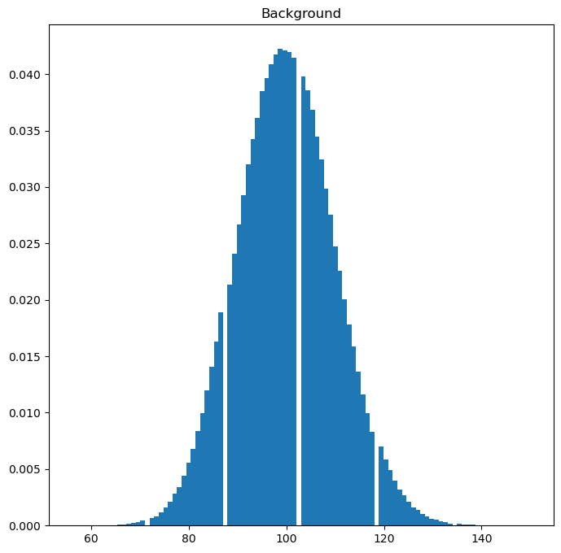

```python
bkgd = stats.poisson.rvs(100, loc= 0, size = 1000000)
plt.hist(bkgd, density = True, bins = 100)
plt.title('Background')
plt.show()
```

## Problem 1

The first problem is to look at your background distribution and determine where the 5σ sensitivity threshold is. [Hint, you've done this several times now, look back at the first few labs.]

```python
sigma = 1 - stats.norm.cdf(5)
signal = stats.poisson.ppf(1 - sigma, mu = 100)
signal
```

```
154.0
```

The required signal for 5 sigma significance is 154

## Problem 2

Now inject a signal of known strength. You will want to make your signal moderately strong, say somewhere in the 8-30σ range. Inject this signal into your background data many times.

a) Histogram how bright the observed signal appears to be, and discuss it's shape. Say in words what this histogram is telling you.

```python
# I said the signal in 8 sigma range.
sigma = 1 - stats.norm.cdf(8)
signal = stats.poisson.ppf(1 - sigma, mu = 100)
print('With 8 sigma discovery, the required signal is ', signal)
```

```
With 8 sigma discovery, the required signal is  190.0
```

```python
new_bkgd = bkgd
for i in range(1000):
    new_bkgd[random.randint(0, 100000)] += signal
```

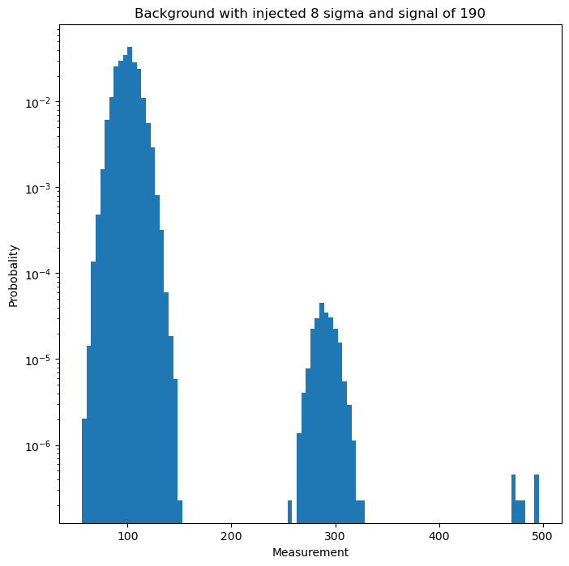

```python
plt.title('Background with injected 8 sigma and signal of 190')
plt.xlabel('Measurement')
plt.ylabel('Probobality')
plt.hist(new_bkgd, density = True, bins = 100)
plt.yscale('log')
plt.show()
```

The hisgtaph tells me that it is poisson distributed with a mean of 100. And the injected signal of 190.

b) Is your observed signal biased? (e.g. is the observed value equally likely to be stronger or weaker than the true injected signal?) Is it symmetric?

Yes. True signal should be 100 less than the observed signal because the faked background has a mean of 100. It is symmetric about 290.

## Problem 3

Now make a suite of injected signals. You will want to have a range of injected signal strengths, starting at zero and extending well above 5σ (30σ or more). You will want to follow the work you did for Homework 5 very closely.

a) Clearly state what you are simulating, and make a 2D histogram of injected signal vs. observed data

We want to inject signals in the range of 0 sigma to 30 sigma.

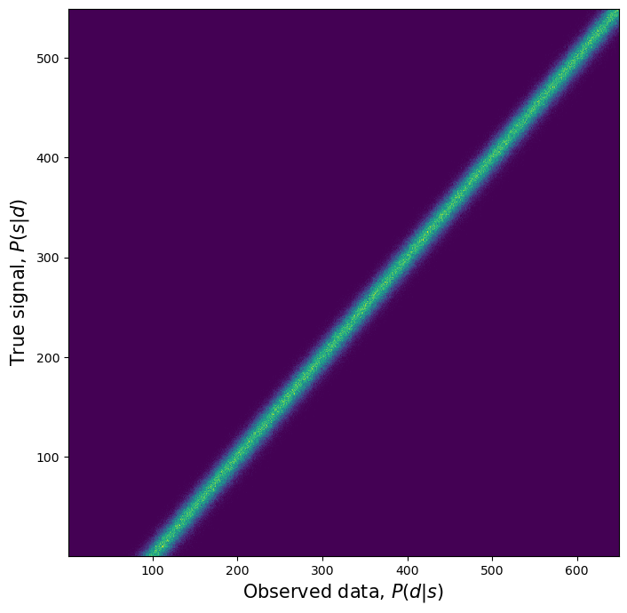

```python
bkgd = scipy.stats.poisson.rvs(100, loc=0, size=1000000)
signal = np.random.uniform(low=0, high=550, size=(1000000))
data = bkgd + signal

signaledges = np.linspace(0,550, 550)
dataedges = np.linspace(0, 650, 650)

Psd, temp, temp2= np.histogram2d(data, signal, bins=[dataedges, signaledges], density=True)

datacenters = (dataedges[:-1] + dataedges[1:]) / 2
signalcenters = (signaledges[:-1] + signaledges[1:]) / 2
plt.pcolormesh(datacenters, signalcenters, Psd.T)
plt.ylabel('True signal, $P(s|d)$', fontsize = 15)
plt.xlabel('Observed data, $P(d|s)$', fontsize = 15)
plt.show()
```

b) For the same injected signal power as in problem 2, show that you get the same answer.

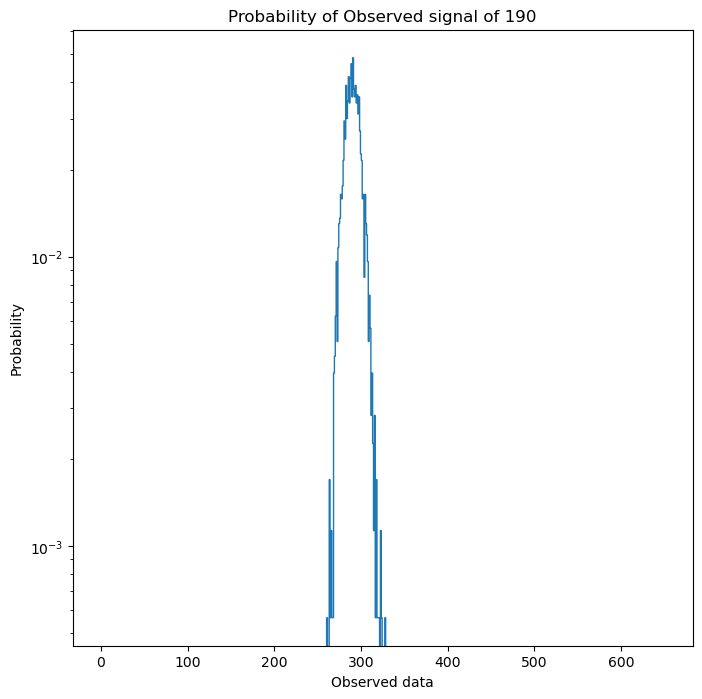

```python
bin_signal = np.digitize(190, signaledges)
data = Psd[:, bin_signal]
data = data*(1/np.sum(data))
plt.stairs(data, edges = dataedges)
plt.title(f'Probability of Observed signal of 190')
plt.ylabel('Probability')
plt.xlabel('Observed data')
plt.yscale('log')
plt.show()
```

As we can see. it matches from the problem 2, it symmetric about 290

c) Now reverse the problem, select an observed data value (pick something quite a bit stronger than 5σ) and create a 1D histogram of the true signal probability given the observed data. Describe the meaning of this histogram.

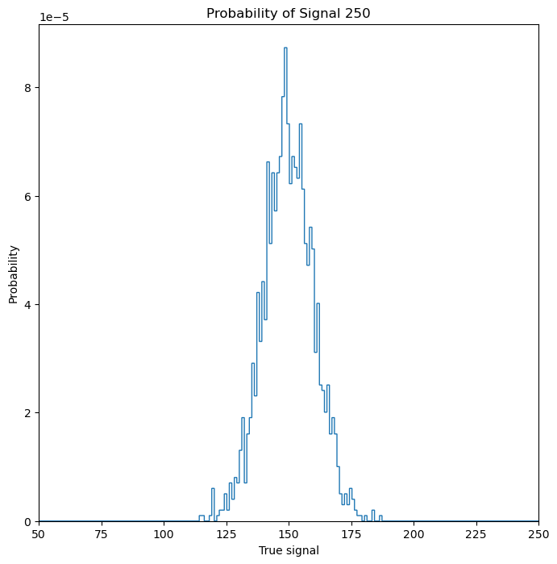

```python
observedsignal = 250
observedbin = np.digitize(observedsignal, dataedges) - 1
prob = Psd[observedbin, :]
plt.stairs(prob, edges = signaledges)
plt.title('Probability of Signal 250')
plt.ylabel('Probability')
plt.xlabel('True signal')
plt.xlim(50, 250)
plt.show()
```

We can see from this histogram, the observe a signal of 250, the true signal is about 150 because the background adds 100 to the observed signal.

d) For your observed signal, what is the 1σ uncertainty on the true signal strength?

```python
prob = stats.norm.cdf(1)
print(prob)
```

```
0.8413447460685429
```

```python
observed = np.ones(1000000)*observedsignal
injection = observed - bkgd
mean = injection.mean()
std = injection.std()
upbound = stats.norm.isf(stats.norm.sf(1), loc=mean, scale=std)
lowbound = stats.norm.isf(stats.norm.cdf(1), loc=mean, scale=std)
print('the lower bound is ', lowbound)
print('the upper bound is ', upbound)
```

```
the lower bound is  139.99079447819895
the upper bound is  159.99348952180105
```

e) Discuss the answer to part d in some depth. Is it symmetric? Is it biased? Does this make sense?

The observed signal is biased and symmetric. It is biased by 100 and it is symmetric about the mean.